# Biostat 212a Homework 5

## 0.3 Support vector machines (SVMs) on the `Carseats` data set (30pts)

Follow the machine learning workflow to train support vector classifier (same as SVM with linear kernel), SVM with polynomial kernel (tune the degree and regularization parameter $C$), and SVM with radial kernel (tune the scale parameter $\gamma$ and regularization parameter $C$) for classifying `Sales<=8` versus `Sales>8`. Use the same seed as in your HW4 for the initial test/train split and compare the final test AUC and accuracy to those methods you tried in HW4.

# 1 linear kernel

```r
# Load libraries
library(GGally)
library(gtsummary)
library(kernlab)
library(tidyverse)
library(tidymodels)

data("Carseats", package = "ISLR2")
```

```r
High <- factor(ifelse(Carseats$Sales <= 8, "No", "Yes"))
Carseats_class <- data.frame(Carseats, High)
Carseats_class <- Carseats_class %>% select(-Sales)

# For reproducibility
set.seed(123)
data_split <- initial_split(
  Carseats_class,
  prop = 0.5,
  strata = "High"
  )
data_split
```

```
<Training/Testing/Total>
<200/200/400>
```

```r
Carseats_other <- training(data_split)
dim(Carseats_other)
```

```
[1] 200  11
```

```r
Carseats_test <- testing(data_split)
dim(Carseats_test)
```

```
[1] 200  11
```

```r
svm_recipe <-
  recipe(
    High ~ .,
    data = Carseats_other
  ) %>%
  step_naomit(all_predictors()) %>%
  step_dummy(all_nominal_predictors()) %>%
  step_zv(all_numeric_predictors()) %>%
  step_normalize(all_numeric_predictors())
svm_recipe
```

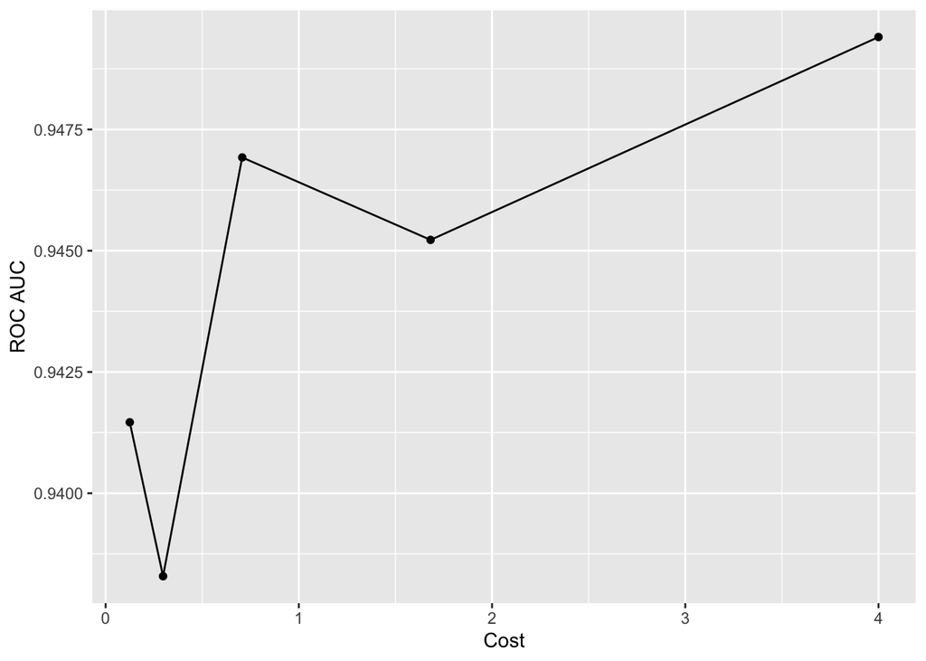

```r
# Specify the SVM model with a linear kernel
svm_mod <- svm_linear(
  mode = "classification",
  cost = tune()
) %>%
set_engine("kernlab")

# Create the workflow with the recipe and model
svm_wf <- workflow() %>%
add_recipe(svm_recipe) %>%
add_model(svm_mod)

# Define the grid for hyperparameter tuning
param_grid <- grid_regular(
  cost(range = c(-3, 2)),
  levels = c(5)
)

# Prepare for cross-validation
set.seed(123)
folds <- vfold_cv(Carseats_other, v = 5)

# Tune the model with the training set
svm_fit <- svm_wf %>%
  tune_grid(
    resamples = folds,
    grid = param_grid,
    metrics = metric_set(roc_auc, accuracy)
  )

svm_fit %>%
  collect_metrics() %>%
  filter(.metric == "roc_auc") %>%
  ggplot(mapping = aes(x = cost, y = mean)) + # Use 'cost' instead of 'degree'
  geom_point() +
  geom_line() +
  labs(x = "Cost", y = "ROC AUC") +
  scale_x_continuous() # Use a continuous scale for cost
```

```r
# Finalize the workflow with the best parameters
best_svm <- select_best(svm_fit, metric = "roc_auc")
final_wf <- finalize_workflow(svm_wf, best_svm)

# Fit the final model on the full training dataset
final_fit <- last_fit(final_wf, split = data_split)

# Collect metrics for the final model
final_fit %>%
  collect_metrics()
```

```
# A tibble: 2 × 4
  .metric  .estimator .estimate .config
  <chr>    <chr>          <dbl> <chr>
1 accuracy binary         0.91  Preprocessor1_Model1
2 roc_auc  binary         0.967 Preprocessor1_Model1
```

# 2 ploynomial kernel

```r
svm_mod <-
  svm_poly(
    mode = "classification",
    cost = tune(),
    degree  = tune()
  ) %>%
  set_engine("kernlab")
svm_mod
```

```
Polynomial Support Vector Machine Model Specification (classification)

Main Arguments:
  cost = tune()
  degree = tune()

Computational engine: kernlab
```

```r
svm_wf <- workflow() %>%
  add_recipe(svm_recipe) %>%
  add_model(svm_mod)
svm_wf
```

```
══ Workflow ════════════════════════════════════════════════════════════════════
Preprocessor: Recipe
Model: svm_poly()

── Preprocessor ────────────────────────────────────────────────────────────────
4 Recipe Steps

• step_naomit()
• step_dummy()
• step_zv()
• step_normalize()

── Model ───────────────────────────────────────────────────────────────────────
Polynomial Support Vector Machine Model Specification (classification)

Main Arguments:
  cost = tune()
  degree = tune()

Computational engine: kernlab
```

```r
param_grid <- grid_regular(
  cost(range = c(-3, 2)),
  degree(range = c(1, 5)),
  levels = c(5)
  )
param_grid
```

```
# A tibble: 25 × 2
    cost degree
   <dbl>  <dbl>
 1 0.125      1
 2 0.297      1
 3 0.707      1
 4 1.68       1
 5 4          1
 6 0.125      2
 7 0.297      2
 8 0.707      2
 9 1.68       2
10 4          2
# ℹ 15 more rows
```

```r
set.seed(123)

folds <- vfold_cv(Carseats_other, v = 5)
folds
```

```
#  5-fold cross-validation
# A tibble: 5 × 2
  splits           id
  <list>           <chr>
1 <split [160/40]> Fold1
2 <split [160/40]> Fold2
3 <split [160/40]> Fold3
4 <split [160/40]> Fold4
5 <split [160/40]> Fold5
```

```r
svm_fit <- svm_wf %>%
  tune_grid(
    resamples = folds,
    grid = param_grid,
    metrics = metric_set(roc_auc, accuracy)
    )
svm_fit
```

```
# Tuning results
# 5-fold cross-validation
# A tibble: 5 × 4
  splits           id    .metrics          .notes
  <list>           <chr> <list>            <list>
1 <split [160/40]> Fold1 <tibble [50 × 6]> <tibble [0 × 3]>
2 <split [160/40]> Fold2 <tibble [50 × 6]> <tibble [0 × 3]>
3 <split [160/40]> Fold3 <tibble [50 × 6]> <tibble [0 × 3]>
4 <split [160/40]> Fold4 <tibble [50 × 6]> <tibble [0 × 3]>
5 <split [160/40]> Fold5 <tibble [50 × 6]> <tibble [0 × 3]>
```

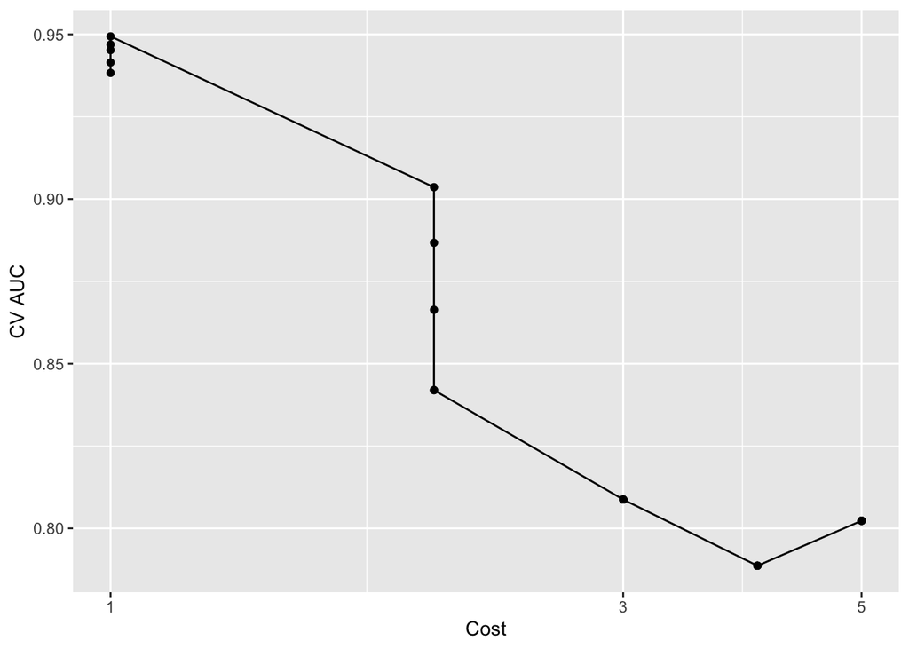

```r
svm_fit %>%
  collect_metrics() %>%
  filter(.metric == "roc_auc") %>%
  ggplot(mapping = aes(x = degree, y = mean)) +
  geom_point() +
  geom_line() +
  labs(x = "Cost", y = "CV AUC") +
  scale_x_log10()
```

```r
svm_fit %>%
  show_best("roc_auc")
```

```
# A tibble: 5 × 8
   cost degree .metric .estimator  mean     n std_err .config
  <dbl>  <dbl> <chr>   <chr>      <dbl> <int>   <dbl> <chr>
1 4          1 roc_auc binary     0.949     5 0.00707 Preprocessor1_Model05
2 0.707      1 roc_auc binary     0.947     5 0.0115  Preprocessor1_Model03
3 1.68       1 roc_auc binary     0.945     5 0.0101  Preprocessor1_Model04
4 0.125      1 roc_auc binary     0.941     5 0.00996 Preprocessor1_Model01
5 0.297      1 roc_auc binary     0.938     5 0.00937 Preprocessor1_Model02
```

```r
best_svm <- svm_fit %>%
  select_best("roc_auc")
best_svm
```

```
# A tibble: 1 × 3
   cost degree .config
  <dbl>  <dbl> <chr>
1     4      1 Preprocessor1_Model05
```

```r
final_wf <- svm_wf %>%
  finalize_workflow(best_svm)
final_wf
```

```
══ Workflow ════════════════════════════════════════════════════════════════════
Preprocessor: Recipe
Model: svm_poly()

── Preprocessor ────────────────────────────────────────────────────────────────
4 Recipe Steps

• step_naomit()
• step_dummy()
• step_zv()
• step_normalize()

── Model ───────────────────────────────────────────────────────────────────────
Polynomial Support Vector Machine Model Specification (classification)

Main Arguments:
  cost = 4
  degree = 1

Computational engine: kernlab
```

```r
final_fit <-
  final_wf %>%
  last_fit(data_split)
final_fit
```

```
# Resampling results
# Manual resampling
# A tibble: 1 × 6
  splits            id               .metrics .notes   .predictions .workflow
  <list>            <chr>            <list>   <list>   <list>       <list>
1 <split [200/200]> train/test split <tibble> <tibble> <tibble>     <workflow>
```

```r
final_fit %>%
  collect_metrics()
```

```
# A tibble: 2 × 4
  .metric  .estimator .estimate .config
  <chr>    <chr>          <dbl> <chr>
1 accuracy binary         0.91  Preprocessor1_Model1
2 roc_auc  binary         0.967 Preprocessor1_Model1
```

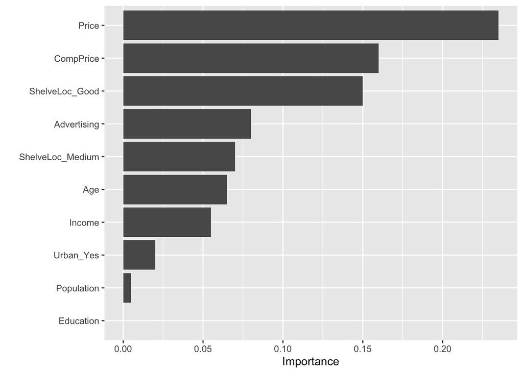

```r
library(doParallel)
set.seed(123)
split_obj <- initial_split(
  Carseats_class,
  prop = 0.5,
  strata = "High"
  )
train <- training(split_obj)
test <- testing(split_obj)

recipe(
    High ~ .,
    data = Carseats_other
  ) %>%
  step_naomit(all_predictors()) %>%
  step_dummy(all_nominal_predictors()) %>%
  step_zv(all_numeric_predictors()) %>%
  step_normalize(all_numeric_predictors()) %>%
  prep() -> recipe_obj

train <- bake(recipe_obj, new_data=train)
test <- bake(recipe_obj, new_data=test)

library(vip)
final_fit %>%
  pluck(".workflow", 1) %>%
  pull_workflow_fit() %>%
  # vip(method = "permute", train= Heart)
  vip(method = "permute",
      target = "High", metric = "accuracy",
      pred_wrapper = kernlab::predict, train = train)
```

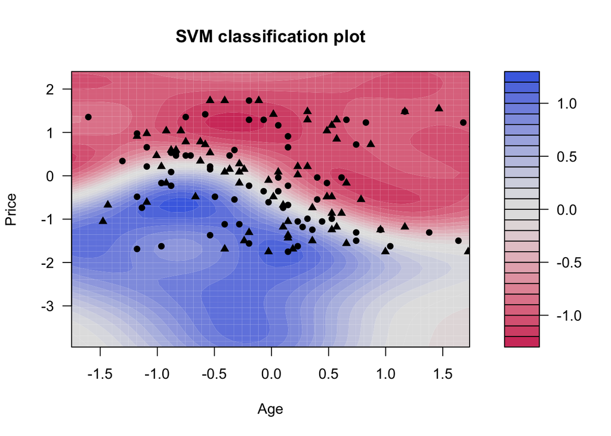

```r
svm_rbf_spec <- svm_rbf() %>%
  set_mode("classification") %>%
  set_engine("kernlab")


svm_rbf_spec <- svm_rbf() %>%
  set_mode("classification") %>%
  set_engine("kernlab")

svm_rbf_fit <- svm_rbf_spec %>%
  fit(High ~ ., data = train[, c('Price', 'Age','High')])

svm_rbf_fit %>%
  extract_fit_engine() %>%
  plot()
```